# CS 422 Section 01

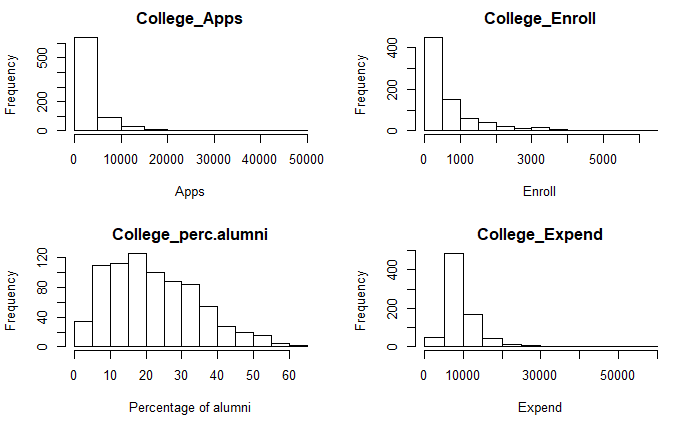

```r
hist(college$perc.alumni, xlab ="Percentage of alumni", main="College_perc.alumni")
hist(college$Expend, xlab ="Expend", main="College_Expend")
```

7. Summary Of the data: 1.From the plot Outstate Vs Private we can see that Public universities has less out of state tuition than Private universities.

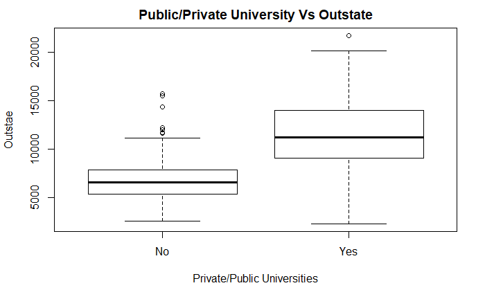

```r
plot(college$Private,college$Outstate,xlab="Private/Public Universities",ylab="Outstae",main="Public/Private University Vs Outstate")
```

2.From the plot Outstate Vs Elite universities Elite universities have more out of state tuition than the non-Elite universities.

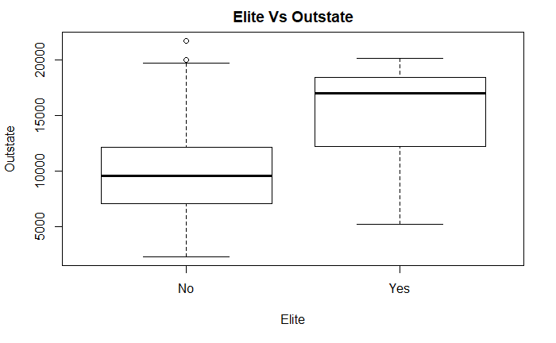

```r
plot(college$Elite,college$Outstate,xlab="Elite",ylab="Outstate",main="Elite Vs Outstate")
```

3.If the out of state tuition increases Graduation rate also increases.

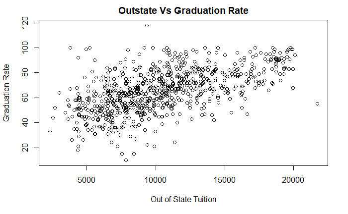

```r
plot(college$Outstate, college$Grad.Rate,xlab = "Out of State Tuition",ylab = "Graduation Rate", main="Outstate Vs Graduation Rate")
```

4.Public Universities has more number of students enrolled than the private universities.

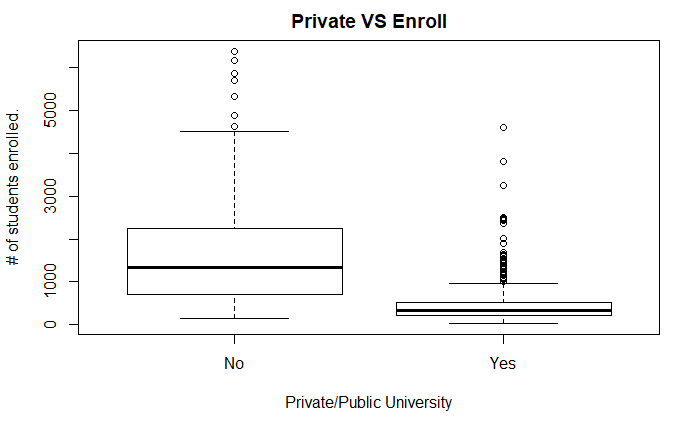

```r
plot(college$Private,college$Enroll,xlab="Private/Public University",ylab="# of students enrolled.", main="Private VS Enroll")
```

5. Public universities have more percent of faculty with Phd’s.

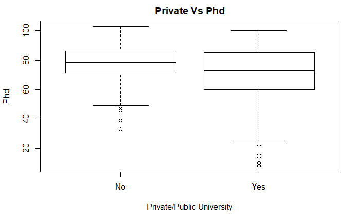

```r
plot(college$Private,college$PhD,xlab="Private/Public University",ylab="Phd", main="Private Vs Phd")
```

6. Public universities have more Student/Faculty Ratio than Private Universities.

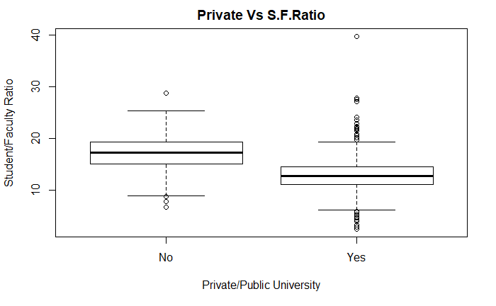

```r
plot(college$Private,college$S.F.Ratio,xlab="Private/Public University",ylab="Student/Faculty Ratio", main="Private Vs S.F.Ratio")
```

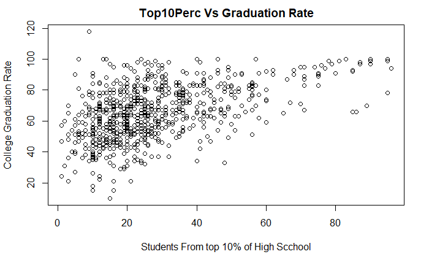

```r
plot(college$Top10perc, college$Grad.Rate,xlab="Students From top 10% of High Scchool", ylab = "College Graduation Rate", main = "Top10Perc Vs Graduation Rate")
```

8.Private universities have higher No of Students accepted to enrolled ratio.

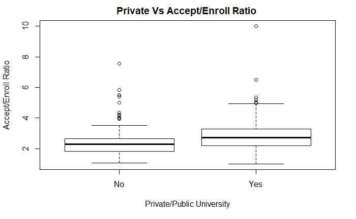

```r
plot(college$Private,college$Accept/college$Enroll,xlab="Private/Public University", ylab="Accept/Enroll Ratio", main="Private Vs Accept/Enroll Ratio ")
```

9. Gratuation Rate in Private Universities are higher than the Public Universities.

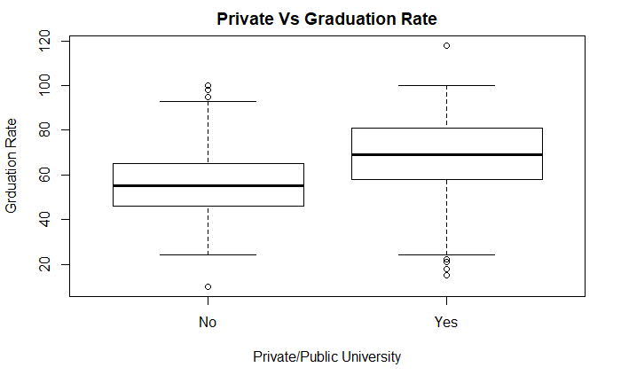

```r
plot(college$Private,college$Grad.Rate,xlab="Private/Public University",ylab="Grduation Rate",main="Private Vs Graduation Rate")
```

10. Public universities have higher number of Full-time and Part-time Undergraduates than private universities.

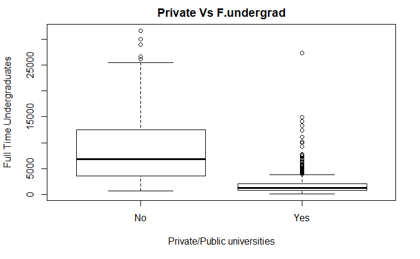

```r
plot(college$Private,college$F.Undergrad,xlab="Private/Public universities",ylab="Full Time Undergraduates", main="Private Vs F.undergrad")
```

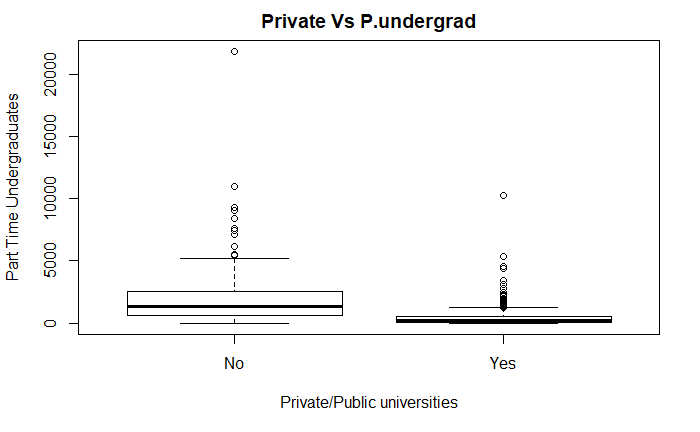

```r
plot(college$Private,college$P.Undergrad,xlab="Private/Public universities",ylab="Part Time Undergraduates", main="Private Vs P.undergrad")
```

11.Public university students spends more for their personal needs.

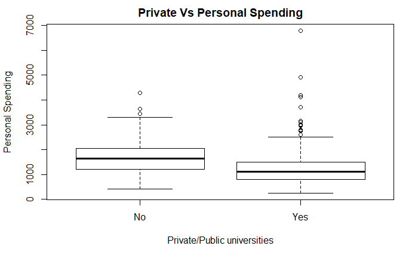

```r
plot(college$Private,college$Personal,xlab="Private/Public universities",ylab="Personal Spending",main="Private Vs Personal Spending")
```

12. Higher the Instructonal expenditure per student higher the graduation rate. Also most of the universities have less than $20000 as their Instructional expenditure.

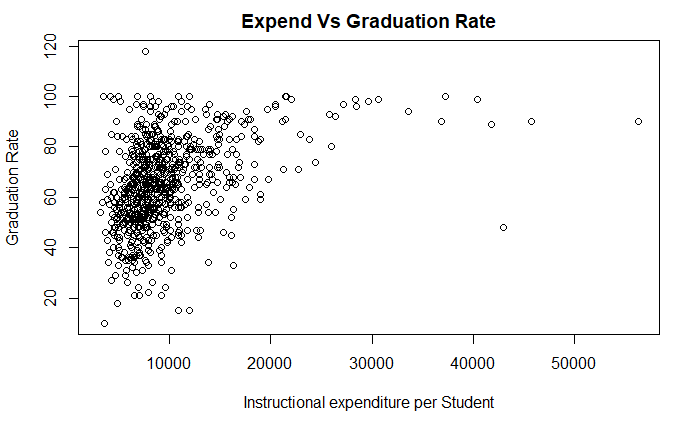

```r
plot(college$Expend,college$Grad.Rate,xlab = "Instructional expenditure per Student", ylab = "Graduation Rate" , main="Expend Vs Graduation Rate")
```

13. Alumini of Private Universities donate more than the Alumini of Public universities.

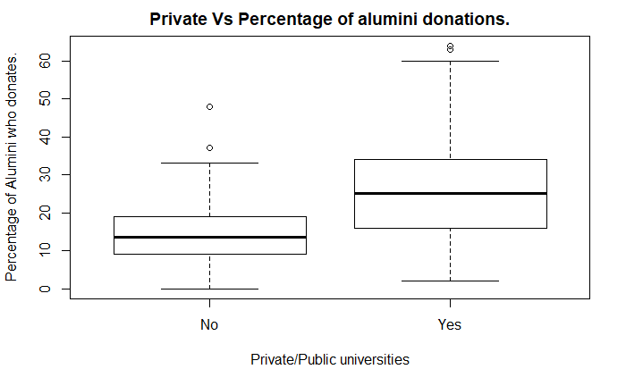

```r
plot(college$Private,college$perc.alumni,xlab="Private/Public universities",ylab="Percentage of Alumini who donates.",main="Private Vs Percentage of alumini donations.")
```

Problem 2.2:

Linear Regression:

```r
setwd("E:/IIT CHICAGO STUDIES/IIT Chicago semester 2/Data Mining/Assignments/Assignment1")
Nba_df <- read.csv("nba.csv",header = TRUE,sep=",")
head(Nba_df)
```

|  | SEASON | DATE | PLAYER.FULLNAME | POSITION | OWNTEAM | OPPTEAM | VENUE | MIN | FG | FGA | X3P | X3PA | FT | FTA | OR | DR | TOT | A | PF | ST | TO | BL | PTS |
| --- | --- | --- | --- | --- | --- | --- | --- | --- | --- | --- | --- | --- | --- | --- | --- | --- | --- | --- | --- | --- | --- | --- | --- |
| 1 | 2017-2018 Regular Season | 10/17/2017 | Gordon Hayward | SF | Boston | Cleveland | R | 5.3 | 1 | 2 | 0 | 1 | 0 | 0 | 0 | 1 | 1 | 0 | 1 | 0 | 0 | 0 | 2 |
| 2 | 2017-2018 Regular Season | 10/17/2017 | Jayson Tatum | SF | Boston | Cleveland | R | 36.5 | 5 | 12 | 1 | 2 | 3 | 3 | 4 | 6 | 10 | 3 | 4 | 0 | 1 | 0 | 14 |
| 3 | 2017-2018 Regular Season | 10/17/2017 | Al Horford | C | Boston | Cleveland | R | 32.1 | 2 | 7 | 0 | 2 | 5 | 7 | 0 | 7 | 7 | 5 | 2 | 0 | 0 | 1 | 9 |
| 4 | 2017-2018 Regular Season | 10/17/2017 | Jaylen Brown | SF | Boston | Cleveland | R | 39.6 | 11 | 23 | 2 | 9 | 1 | 2 | 1 | 5 | 6 | 0 | 5 | 2 | 3 | 0 | 25 |
| 5 | 2017-2018 Regular Season | 10/17/2017 | Kyrie Irving | PG | Boston | Cleveland | R | 39.4 | 8 | 17 | 4 | 9 | 2 | 2 | 2 | 2 | 4 | 10 | 4 | 3 | 2 | 0 | 22 |
| 6 | 2017-2018 Regular Season | 10/17/2017 | Marcus Smart | PG | Boston | Cleveland | R | 35.1 | 5 | 16 | 0 | 4 | 2 | 3 | 0 | 9 | 9 | 3 | 2 | 2 | 2 | 2 | 12 |

```r
# Finding predictor with strong correlation with the PTS variable
Strong_corr <- suppressWarnings(cor(cbind(Nba_df$SEASON,Nba_df$DATE,Nba_df$PLAYER.FULLNAME,Nba_df$POSITION,Nba_df$OWNTEAM,Nba_df$OPPTEAM,Nba_df$VENUE,Nba_df$MIN,Nba_df$FG,Nba_df$FGA,Nba_df$X3P,Nba_df$X3PA,Nba_df$FT,Nba_df$FTA,Nba_df$OR,Nba_df$DR,Nba_df$TOT,Nba_df$A,Nba_df$PF,Nba_df$ST,Nba_df$TO,Nba_df$BL,Nba_df$PTS)))
Strong_corr[,23]
```

```
 [1]          NA -0.03534700 -0.07732901  0.07720249 -0.01377385 -0.05918672  0.02607913
 [8]  0.71977791  0.95741470  0.86671000  0.54053488  0.53854424  0.63931781  0.62758211
[15]  0.35450148  0.45675074  0.49163052  0.38007076  0.25702105  0.27166358  0.43687361
[22]  0.21732545  1.00000000
```

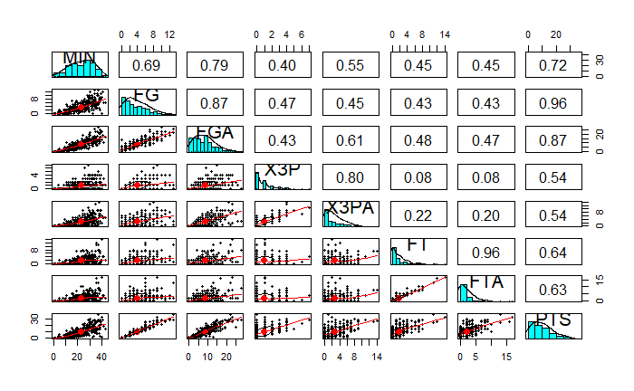

```r
#Graph containing the correlations
library(psych)
pairs.panels(Nba_df[,c(8:14,23)])
```

```r
#Priting the selected Predictor
choosen_column <- colnames(Nba_df[9])
cat(paste("The selected predictor is : ",choosen_column))
```

```
The selected predictor is :  FG
```

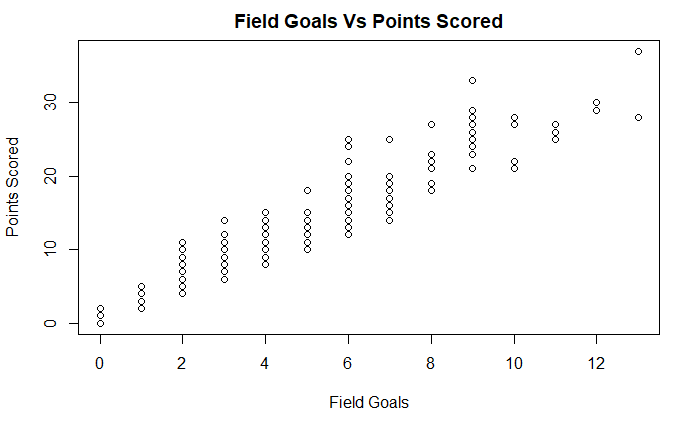

```r
#Correlation Plot
Cor_Plot <- Nba_df[,c(9,23)]
plot(Cor_Plot$FG,Cor_Plot$PTS,xlab = "Field Goals",ylab = "Points Scored",main="Field Goals Vs Points Scored")
```

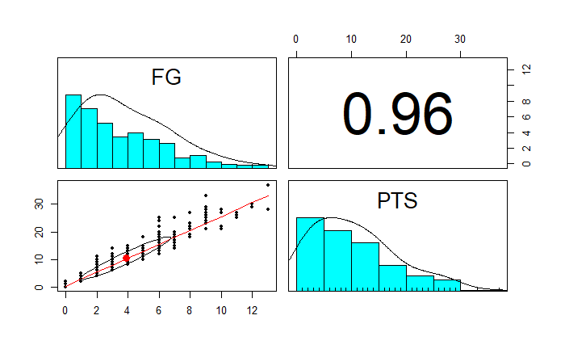

```r
pairs.panels(Cor_Plot)
```

```r
#linear regression model
Linear_Reg_model <- lm(PTS ~ FG, data=Nba_df)
summary(Linear_Reg_model)
```

```
Call:
lm(formula = PTS ~ FG, data = Nba_df)

Residuals:
    Min      1Q  Median      3Q     Max
-5.7986 -1.2524 -0.3616  0.8569  9.4199

Coefficients:
            Estimate Std. Error t value Pr(>|t|)
(Intercept)  0.58848    0.22751   2.587   0.0102 *
FG           2.55462    0.04715  54.186   <2e-16 ***
---
Signif. codes:  0 ‘***’ 0.001 ‘**’ 0.01 ‘*’ 0.05 ‘.’ 0.1 ‘ ’ 1

Residual standard error: 2.241 on 267 degrees of freedom
Multiple R-squared:  0.9166,    Adjusted R-squared:  0.9163
F-statistic:  2936 on 1 and 267 DF,  p-value: < 2.2e-16
```

```r
anova(Linear_Reg_model)
```

```
Analysis of Variance Table

Response: PTS
           Df  Sum Sq Mean Sq F value    Pr(>F)
FG          1 14740.0   14740  2936.1 < 2.2e-16 ***
Residuals 267  1340.4       5
---
Signif. codes:  0 ‘***’ 0.001 ‘**’ 0.01 ‘*’ 0.05 ‘.’ 0.1 ‘ ’ 1
```

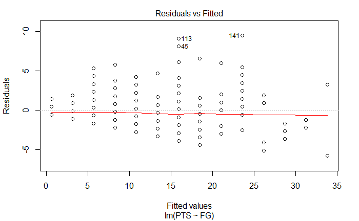

```r
plot(Linear_Reg_model,1)
```

How well the model fits the data?

1. Here Beta_1 = 2.55 . So there is atleast one Predictor helpful in predicting the response and here Probability is vey low (2e-16) which state that Predictor is strongly correlated with the response.
2. Here Beta_1 is positive, So increase in Fg value has a positive effect on PTS(response).
3. Here we are able to capture 91.6% of the variance using this value as the R square value is 0.9163.
4. Since the F-statistic value is 2936 > 1 here n= 269 observations so the model is good.
5. Two statistics tells us how well the model fits the data sample RSE and R^2. Form the anova command we can see that FG predictor has high variance. Here RSE = 2.241 and R Square vaule is 0.916.
6. From the residual plot we can infer that data points are equally shared above and below the regression line.

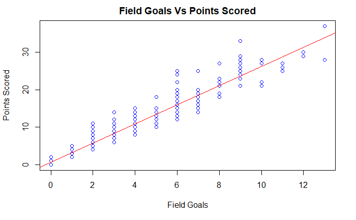

```r
#X-Y Plot of predictor and the regressor.
plot(Nba_df$FG,Nba_df$PTS,xlab = "Field Goals",ylab = "Points Scored",main="Field Goals Vs Points Scored",col="blue")
abline(Linear_Reg_model,col="Red")
```

```r
#setting seed and dividing data set into train and test
set.seed(1122)
index <- sample(1:nrow(Nba_df), 250)
train <- Nba_df[index, ]
test <- Nba_df[-index, ]
```

3. Predictors choosen –> MIN,FG,FT

I have choosen FT over FGA because FGA has high inter correlation with the other predictors.

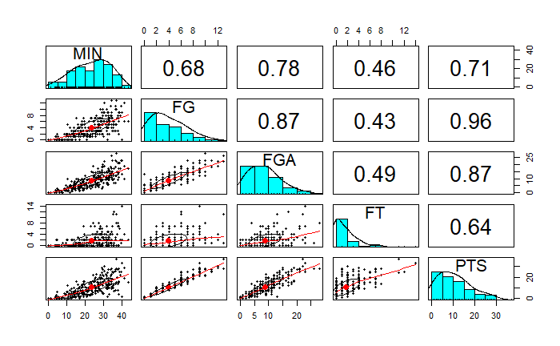

```r
pairs.panels(train[,c(8,9,10,13,23)])
```

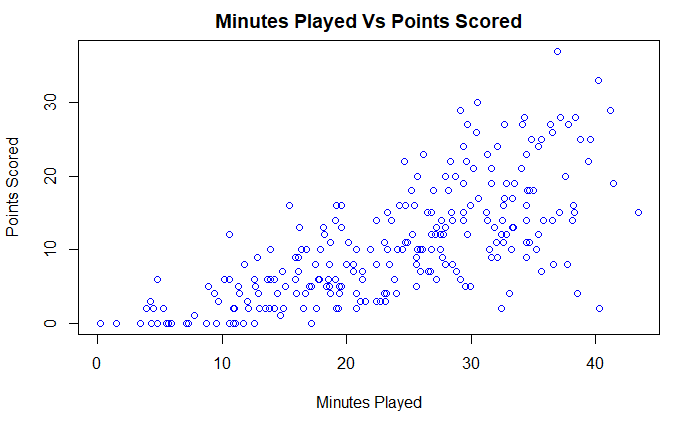

```r
plot(train$MIN,train$PTS,xlab = "Minutes Played",ylab = "Points Scored",main="Minutes Played Vs Points Scored",col="blue")
```

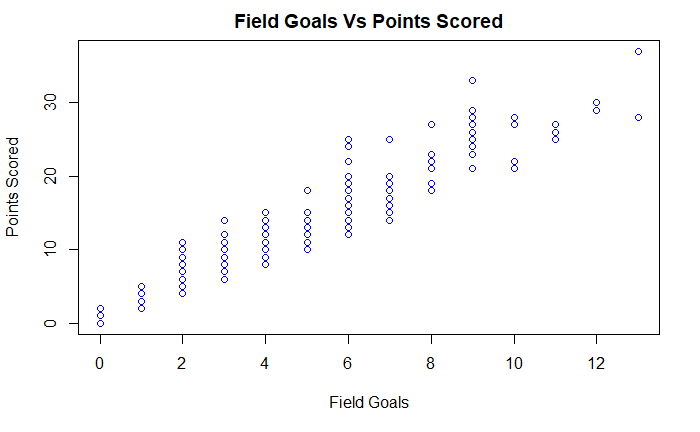

```r
plot(train$FG,train$PTS,xlab = "Field Goals",ylab = "Points Scored",main="Field Goals Vs Points Scored",col="blue")
```

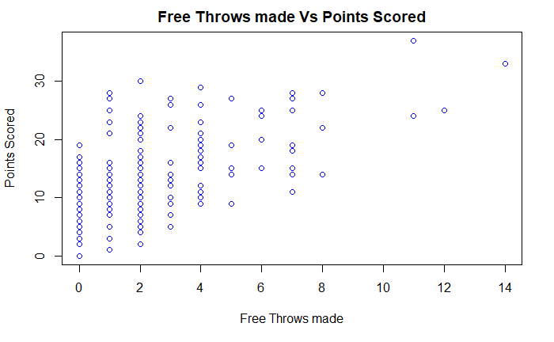

```r
#plot(Nba_df$FGA,Nba_df$PTS,xlab = "Field Goals Attempted",ylab = "Points Scored",main="Field Goals Attempted Vs Points Scored",col="blue")
plot(train$FT,train$PTS,xlab = "Free Throws made",ylab = "Points Scored",main="Free Throws made Vs Points Scored",col="blue")
```

Multiple Regression:

```r
Multi_Reg_model <- lm(PTS ~ MIN+FG+FT, data=train)
summary(Multi_Reg_model)
```

```
Call:
lm(formula = PTS ~ MIN + FG + FT, data = train)

Residuals:
    Min      1Q  Median      3Q     Max
-2.3700 -0.7151 -0.1265  0.5014  5.1828

Coefficients:
            Estimate Std. Error t value Pr(>|t|)
(Intercept) -0.19155    0.18818  -1.018  0.30973
MIN          0.02699    0.01024   2.635  0.00895 **
FG           2.18102    0.03401  64.134  < 2e-16 ***
FT           0.89856    0.03462  25.952  < 2e-16 ***
---
Signif. codes:  0 ‘***’ 0.001 ‘**’ 0.01 ‘*’ 0.05 ‘.’ 0.1 ‘ ’ 1

Residual standard error: 1.136 on 246 degrees of freedom
Multiple R-squared:  0.9794,    Adjusted R-squared:  0.9792
F-statistic:  3907 on 3 and 246 DF,  p-value: < 2.2e-16
```

```r
anova(Multi_Reg_model)
```

```
Analysis of Variance Table

Response: PTS
           Df Sum Sq Mean Sq F value    Pr(>F)
MIN         1 7896.9  7896.9  6115.7 < 2.2e-16 ***
FG          1 6368.9  6368.9  4932.3 < 2.2e-16 ***
FT          1  869.7   869.7   673.5 < 2.2e-16 ***
Residuals 246  317.6     1.3
---
Signif. codes:  0 ‘***’ 0.001 ‘**’ 0.01 ‘*’ 0.05 ‘.’ 0.1 ‘ ’ 1
```

Comment on the Model:

6.From the results of the anova command we can infer that variance is high and probabily is low indicating that the model is good.

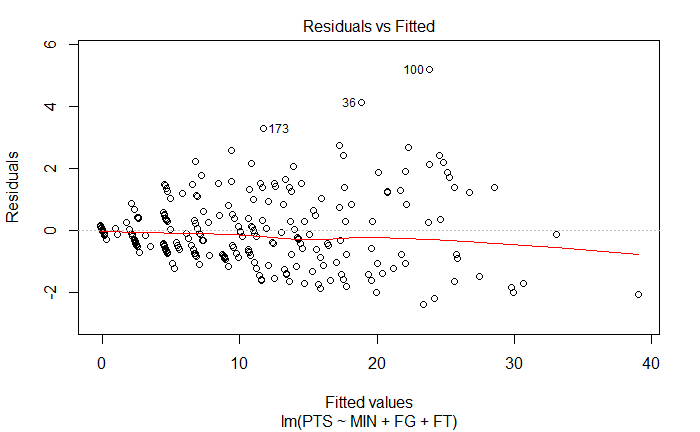

```r
#Residual Model Graph
plot(Multi_Reg_model, 1)
```

The data points in the Residual plot are equally shared above and below the regression line.So that the residual error is minimised and the model is a good predictor of the response.

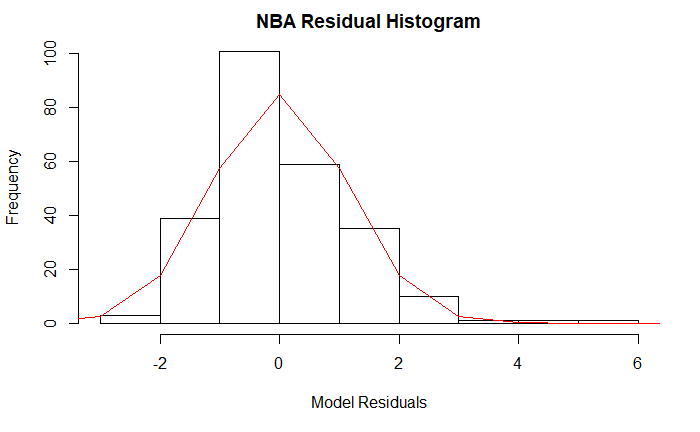

```r
# Histogram of the residual plot
hist(Multi_Reg_model$residuals, xlab = "Model Residuals",
     main="NBA Residual Histogram")
x <- -7:7
lines(x, 240*dnorm(x, 0, sd(Multi_Reg_model$residuals)), col=2)
```

```r
library("moments")
skewness(Multi_Reg_model$residuals)  #Right skewed So its not normally distributed.
```

```
[1] 0.8964666
```

The residuals do not look exactly like a Gaussian distribution; a bit Right skewed with skewness 0.896.

```r
predict_values <- predict.lm(Multi_Reg_model,test, interval="prediction")
predict_values
```

```
            fit         lwr       upr
6   13.45791359 11.20671739 15.709110
9    8.29098255  6.03804776 10.543917
28  13.52605590 11.27432807 15.777784
133 10.30277257  8.05145159 12.554094
134 17.02393732 14.76402724 19.283847
139  2.30522345  0.05577576  4.554671
149 -0.16995547 -2.43666322  2.096752
159  5.48195441  3.23615236  7.727756
168  4.53481673  2.28707059  6.782563
191  2.15679257 -0.09972797  4.413313
199  9.00682327  6.75427235 11.259374
221  8.32606622  6.07342355 10.578709
222 14.94737746 12.69968368 17.195071
223  4.51862427  2.27034890  6.766900
229  4.91803828  2.66379970  7.172277
234  9.14513291  6.89917086 11.391095
248  2.27553728  0.02511090  4.525964
258  9.52216202  7.27456185 11.769762
259  0.08372641 -2.16847832  2.335931
```

```r
summary(predict_values)
```

```
      fit              lwr              upr
 Min.   :-0.170   Min.   :-2.437   Min.   : 2.097
 1st Qu.: 3.412   1st Qu.: 1.163   1st Qu.: 5.661
 Median : 8.291   Median : 6.038   Median :10.544
 Mean   : 7.350   Mean   : 5.098   Mean   : 9.602
 3rd Qu.: 9.912   3rd Qu.: 7.663   3rd Qu.:12.162
 Max.   :17.024   Max.   :14.764   Max.   :19.284
```

Creation of data frame with predicted and the actual test data response.

```r
data1 <- cbind(test$PTS,predict_values)
New_data <-data1[,c(2,1)]
colnames(New_data) <- c("Predicted_value", "Actual_Value")
New_data <-data.frame(New_data)
New_data
```

|  | Predicted_value | Actual_Value |
| --- | --- | --- |
| 6 | 13.45791359 | 12 |
| 9 | 8.29098255 | 9 |
| 28 | 13.52605590 | 14 |
| 133 | 10.30277257 | 12 |
| 134 | 17.02393732 | 17 |
| 139 | 2.30522345 | 3 |
| 149 | -0.16995547 | 0 |
| 159 | 5.48195441 | 6 |
| 168 | 4.53481673 | 4 |
| 191 | 2.15679257 | 2 |

[output cut: 9 more lines]

```r
a <- New_data$Actual_Value == New_data$Predicted_value
No_Of_Exact_Match <- sum(a)
cat(paste("Number of Exact matches : ",No_Of_Exact_Match))
```

```
Number of Exact matches :  0
```

Eventhough the number of exact matches are none the predicted and the actual response for the test data is very close to one another.

```r
resi_duals <- New_data$Actual_Value - New_data$Predicted_value
resi_duals
```

```
 [1] -1.457913587  0.709017446  0.473944099  1.697227429 -0.023937319  0.694776548  0.169955465
 [8]  0.518045585 -0.534816728 -0.156792570 -0.006823265  0.673933782 -0.947377462 -0.518624268
[15]  0.081961721  0.854867094  0.724462724 -0.522162021 -0.083726406
```

```r
rss <- sum(resi_duals^2)
rss
```

```
[1] 9.987332
```

```r
tss <-sum((New_data$Actual_Value - mean(New_data$Actual_Value))^2)
tss
```

```
[1] 446.7368
```

```r
#Fstat
n <- 19 # Number of observations
p <- 3  # Nuber of Predictors.
Fstat <- ((tss-rss)/p)/(rss/(n-p-1))
Fstat  # F statistics
```

```
[1] 218.6518
```

```r
#RSE
Rse <- sqrt(rss/(n-p-1))
Rse
```

```
[1] 0.8159792
```